# Credit Card Default: Machine Learning Tools

# 4. Neural Networks (MLP)

## 4.1 Theory

A **Multi-Layer Perceptron (MLP)** is a feedforward neural network composed of an input layer, one or more hidden layers, and an output layer. Each layer applies an affine transformation followed by a non-linear activation:

$$\mathbf{h}^{(l)} = \text{ReLU}\!\left(\mathbf{W}^{(l)}\mathbf{h}^{(l-1)} + \mathbf{b}^{(l)}\right)$$

For binary classification with a single output neuron, the raw output (logit) $z = \mathbf{w}^T\mathbf{h} + b$ is converted to a probability via $\hat{p} = \sigma(z) = (1 + e^{-z})^{-1}$. Training minimises **binary cross-entropy** using stochastic gradient descent (SGD) with **backpropagation** to compute exact gradients.

Key hyperparameters: hidden layer widths, learning rate, dropout probability (regularisation), batch size, and number of training epochs. We use the **Adam** optimiser, which adapts the learning rate per parameter and typically converges faster than vanilla SGD.

## 4.2 Architecture & Data Preparation

```python
import torch
from torch import nn
from torch.utils.data import DataLoader, TensorDataset

device = torch.device('cuda' if torch.cuda.is_available() else 'cpu')
print(f"Device: {device}")

# ── TensorDatasets ────────────────────────────────────────────────────────────
def make_tensor_loaders(X_tr, y_tr, X_te, y_te, batch_size=256,
                        val_frac=0.15, seed=42):
    """
    Splits training data into train/val, creates TensorDatasets and DataLoaders.
    val_frac: fraction of training rows reserved for validation.
    """
    rng_t = torch.Generator().manual_seed(seed)
    n_val = int(len(X_tr) * val_frac)
    n_tr  = len(X_tr) - n_val
    perm  = torch.randperm(len(X_tr), generator=rng_t)

    idx_tr  = perm[:n_tr]
    idx_val = perm[n_tr:]

    X_tr_t  = torch.tensor(X_tr.values,  dtype=torch.float32)
    y_tr_t  = torch.tensor(y_tr.values,  dtype=torch.float32)
    X_te_t  = torch.tensor(X_te.values,  dtype=torch.float32)
    y_te_t  = torch.tensor(y_te.values,  dtype=torch.float32)

    ds_train = TensorDataset(X_tr_t[idx_tr],  y_tr_t[idx_tr])
    ds_val   = TensorDataset(X_tr_t[idx_val], y_tr_t[idx_val])
    ds_test  = TensorDataset(X_te_t,           y_te_t)

    loader_train = DataLoader(ds_train, batch_size=batch_size, shuffle=True)
    loader_val   = DataLoader(ds_val,   batch_size=batch_size, shuffle=False)
    loader_test  = DataLoader(ds_test,  batch_size=batch_size, shuffle=False)

    return loader_train, loader_val, loader_test

loader_train, loader_val, loader_test = make_tensor_loaders(
    X_train_scaled, y_train, X_test_scaled, y_test
)
print(f"Train batches: {len(loader_train)} | "
      f"Val batches: {len(loader_val)} | "
      f"Test batches: {len(loader_test)}")
```

```
Device: cpu
Train batches: 70 | Val batches: 13 | Test batches: 36
```

```python
# ── Model definition ──────────────────────────────────────────────────────────
class CreditDefaultMLP(nn.Module):
    """
    Feedforward MLP for binary credit-default classification.
    Output: single logit (no sigmoid — compatible with BCEWithLogitsLoss).
    """
    def __init__(self, input_dim, hidden1=128, hidden2=64, dropout=0.2):
        super().__init__()
        self.net = nn.Sequential(
            nn.Linear(input_dim, hidden1),
            nn.ReLU(),
            nn.Dropout(dropout),
            nn.Linear(hidden1, hidden2),
            nn.ReLU(),
            nn.Dropout(dropout),
            nn.Linear(hidden2, 1),
        )

    def forward(self, x):
        return self.net(x).squeeze(1)   # (B, 1) → (B,)

input_dim = X_train_scaled.shape[1]
print(f"Input dimension: {input_dim}")

# Quick architecture preview
_model_preview = CreditDefaultMLP(input_dim)
print(_model_preview)
```

```
Input dimension: 24
CreditDefaultMLP(
  (net): Sequential(
    (0): Linear(in_features=24, out_features=128, bias=True)
    (1): ReLU()
    (2): Dropout(p=0.2, inplace=False)
    (3): Linear(in_features=128, out_features=64, bias=True)
    (4): ReLU()
    (5): Dropout(p=0.2, inplace=False)
    (6): Linear(in_features=64, out_features=1, bias=True)
  )
)
```

```python
# ── Training utilities ────────────────────────────────────────────────────────
from sklearn.metrics import roc_auc_score as _auc

def train_one_epoch(model, loader, criterion, optimiser, device):
    """One forward/backward pass over all training mini-batches."""
    model.train()
    total_loss, total = 0.0, 0

    for xb, yb in loader:
        xb, yb = xb.to(device), yb.to(device)
        optimiser.zero_grad()
        logits = model(xb)          # raw logits (no sigmoid)
        loss   = criterion(logits, yb)
        loss.backward()
        optimiser.step()
        total_loss += loss.item() * len(xb)
        total      += len(xb)

    return total_loss / total


def evaluate_loader(model, loader, criterion, device):
    """Return (avg_loss, ROC-AUC) on a DataLoader without gradient tracking."""
    model.eval()
    total_loss, total = 0.0, 0
    all_logits, all_y = [], []

    with torch.no_grad():
        for xb, yb in loader:
            xb, yb = xb.to(device), yb.to(device)
            logits  = model(xb)
            loss    = criterion(logits, yb)
            total_loss += loss.item() * len(xb)
            total      += len(xb)
            all_logits.append(torch.sigmoid(logits).cpu())
            all_y.append(yb.cpu())

    probs  = torch.cat(all_logits).numpy()
    labels = torch.cat(all_y).numpy()
    auc    = _auc(labels, probs)
    return total_loss / total, auc


def fit_mlp(model, loader_train, loader_val, criterion, optimiser,
            epochs, device, verbose_every=5):
    """Full training loop; returns history dict with per-epoch metrics."""
    history = {'train_loss': [], 'val_loss': [],
               'train_auc': [],  'val_auc': []}

    for epoch in range(1, epochs + 1):
        tr_loss                  = train_one_epoch(model, loader_train, criterion,
                                                   optimiser, device)
        tr_loss_eval, tr_auc     = evaluate_loader(model, loader_train, criterion, device)
        val_loss,     val_auc    = evaluate_loader(model, loader_val,   criterion, device)

        history['train_loss'].append(tr_loss_eval)
        history['val_loss'].append(val_loss)
        history['train_auc'].append(tr_auc)
        history['val_auc'].append(val_auc)

        if epoch % verbose_every == 0 or epoch == 1 or epoch == epochs:
            print(f"Epoch {epoch:03d}/{epochs} | "
                  f"train_loss={tr_loss_eval:.4f}, train_auc={tr_auc:.4f} | "
                  f"val_loss={val_loss:.4f}, val_auc={val_auc:.4f}")

    return history


def predict_mlp(model, loader, device):
    """Return (y_true, y_prob) numpy arrays from a DataLoader."""
    model.eval()
    all_probs, all_y = [], []

    with torch.no_grad():
        for xb, yb in loader:
            logits = model(xb.to(device))
            probs  = torch.sigmoid(logits).cpu()
            all_probs.append(probs)
            all_y.append(yb)

    return (torch.cat(all_y).numpy().astype(int),
            torch.cat(all_probs).numpy())


def plot_learning_curves(history, title_prefix='MLP'):
    """Plot loss and AUC curves from history dict."""
    epochs = range(1, len(history['train_loss']) + 1)

    fig, axes = plt.subplots(1, 2, figsize=(13, 4))

    axes[0].plot(epochs, history['train_loss'], label='Train',      color='steelblue')
    axes[0].plot(epochs, history['val_loss'],   label='Validation', color='tab:orange')
    axes[0].set_title(f'{title_prefix} — Loss Curves')
    axes[0].set_xlabel('Epoch')
    axes[0].set_ylabel('BCE Loss')
    axes[0].legend()
    axes[0].grid(True, alpha=0.3)

    axes[1].plot(epochs, history['train_auc'], label='Train',      color='steelblue')
    axes[1].plot(epochs, history['val_auc'],   label='Validation', color='tab:orange')
    axes[1].set_title(f'{title_prefix} — ROC-AUC Curves')
    axes[1].set_xlabel('Epoch')
    axes[1].set_ylabel('ROC-AUC')
    axes[1].legend()
    axes[1].grid(True, alpha=0.3)

    plt.tight_layout()
    plt.show()
```

## 4.3 Baseline Model

A first model is fitted with default hyperparameters to establish a baseline before tuning.

```python
torch.manual_seed(42)

baseline_cfg = dict(hidden1=128, hidden2=64, dropout=0.2, lr=1e-3, epochs=20)

baseline_model = CreditDefaultMLP(
    input_dim, hidden1=baseline_cfg['hidden1'],
    hidden2=baseline_cfg['hidden2'], dropout=baseline_cfg['dropout']
).to(device)

# Standard BCE loss (no pos_weight) for baseline
criterion_base = nn.BCEWithLogitsLoss()
optimiser_base = torch.optim.Adam(baseline_model.parameters(),
                                  lr=baseline_cfg['lr'])

baseline_history = fit_mlp(
    baseline_model, loader_train, loader_val,
    criterion_base, optimiser_base,
    epochs=baseline_cfg['epochs'], device=device, verbose_every=5
)
```

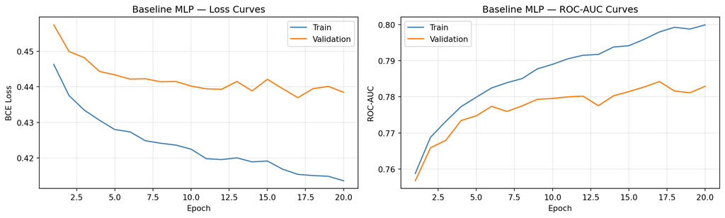

```python
plot_learning_curves(baseline_history, title_prefix='Baseline MLP')
```

```python
y_true_base, y_prob_base = predict_mlp(baseline_model, loader_test, device)
y_pred_base     = (y_prob_base >= 0.50).astype(int)
y_pred_base_opt = (y_prob_base >= opt_t).astype(int)
auc_base        = roc_auc_score(y_true_base, y_prob_base)

print("=== Baseline MLP: Classification Report (t=0.50) ===")
print(classification_report(y_true_base, y_pred_base,
                             target_names=['No Default', 'Default']))
print(f"ROC-AUC: {auc_base:.4f}")
print(f"Expected cost (t=0.50): {expected_cost(y_true_base, y_pred_base):.4f}")
print(f"Expected cost (t={opt_t}): {expected_cost(y_true_base, y_pred_base_opt):.4f}")
```

```
=== Baseline MLP: Classification Report (t=0.50) ===
              precision    recall  f1-score   support

  No Default       0.84      0.94      0.89      7009
     Default       0.64      0.39      0.48      1991

    accuracy                           0.82      9000
   macro avg       0.74      0.66      0.69      9000
weighted avg       0.80      0.82      0.80      9000

ROC-AUC: 0.7716
Expected cost (t=0.50): 0.7248
Expected cost (t=0.2): 0.5659
```

### Interpretation

- The baseline MLP (128 → 64, dropout 0.2, lr = 1e-3, 20 epochs) achieves **ROC-AUC = 0.7716** — already competitive with Random Forest (0.7599) and approaching GBM (0.7809).
- The learning curves show smooth convergence without large train–validation gaps, suggesting the network is not severely overfitting. Validation AUC stabilises near **0.783** by epoch 20.
- At the standard threshold, recall on defaulters is **38.9 %** (F1 = 0.48), marginally better than most tree-based methods at the same threshold. At the cost-optimal threshold 0.20, expected cost is **0.5659**, placing the baseline MLP between GBM and Random Forest.
- These results confirm that even a small, untuned MLP can extract non-linear signal from the standardised tabular features. The next step tests whether larger architectures or different regularisation provide further gains.

## 4.4 Hyperparameter Search

We run a compact manual grid over hidden layer widths, dropout, and learning rate. Each configuration is trained for a short number of epochs on a subset of the training data; the winner is then retrained on the full dataset.

```python
# Subset of training data for fast search (60% of training samples)
rng_np  = np.random.default_rng(42)
tune_n  = int(len(X_train_scaled) * 0.6)
tune_idx_nn = rng_np.choice(len(X_train_scaled), size=tune_n, replace=False)

X_tune_nn = X_train_scaled.iloc[tune_idx_nn].reset_index(drop=True)
y_tune_nn = y_train.iloc[tune_idx_nn].reset_index(drop=True)

loader_train_tune, loader_val_tune, _ = make_tensor_loaders(
    X_tune_nn, y_tune_nn, X_test_scaled, y_test, batch_size=256
)

hp_grid = [
    {'hidden1': 128, 'hidden2':  64, 'dropout': 0.2, 'lr': 1e-3},
    {'hidden1': 256, 'hidden2': 128, 'dropout': 0.2, 'lr': 1e-3},
    {'hidden1': 128, 'hidden2':  64, 'dropout': 0.3, 'lr': 5e-4},
    {'hidden1': 256, 'hidden2': 128, 'dropout': 0.3, 'lr': 5e-4},
    {'hidden1': 256, 'hidden2':  64, 'dropout': 0.2, 'lr': 1e-3},
    {'hidden1': 128, 'hidden2':  64, 'dropout': 0.1, 'lr': 1e-3},
]

N_QUICK = 10   # epochs per candidate during search

hp_results = []
for i, cfg in enumerate(hp_grid, 1):
    torch.manual_seed(42)
    m = CreditDefaultMLP(input_dim, hidden1=cfg['hidden1'],
                         hidden2=cfg['hidden2'], dropout=cfg['dropout']).to(device)
    crit = nn.BCEWithLogitsLoss(pos_weight=torch.tensor([5.0]).to(device))
    opt  = torch.optim.Adam(m.parameters(), lr=cfg['lr'])
    hist = fit_mlp(m, loader_train_tune, loader_val_tune, crit, opt,
                   epochs=N_QUICK, device=device, verbose_every=N_QUICK + 1)
    best_val_auc = max(hist['val_auc'])
    hp_results.append({'config': cfg, 'best_val_auc': best_val_auc})
    print(f"Config {i}/{len(hp_grid)} | val_auc={best_val_auc:.4f} | {cfg}")

hp_results.sort(key=lambda r: r['best_val_auc'], reverse=True)
best_cfg = hp_results[0]['config']

print("\n=== Hyperparameter search ranking ===")
for rank, r in enumerate(hp_results, 1):
    print(f"  {rank}. val_auc={r['best_val_auc']:.4f} | {r['config']}")
print(f"\nBest config: {best_cfg}")
```

```
Config 1/6 | val_auc=0.7903 | {'hidden1': 128, 'hidden2': 64, 'dropout': 0.2, 'lr': 0.001}
Config 2/6 | val_auc=0.7920 | {'hidden1': 256, 'hidden2': 128, 'dropout': 0.2, 'lr': 0.001}
Config 3/6 | val_auc=0.7826 | {'hidden1': 128, 'hidden2': 64, 'dropout': 0.3, 'lr': 0.0005}
Config 4/6 | val_auc=0.7886 | {'hidden1': 256, 'hidden2': 128, 'dropout': 0.3, 'lr': 0.0005}
Config 5/6 | val_auc=0.7905 | {'hidden1': 256, 'hidden2': 64, 'dropout': 0.2, 'lr': 0.001}
Config 6/6 | val_auc=0.7927 | {'hidden1': 128, 'hidden2': 64, 'dropout': 0.1, 'lr': 0.001}

=== Hyperparameter search ranking ===
  1. val_auc=0.7927 | {'hidden1': 128, 'hidden2': 64, 'dropout': 0.1, 'lr': 0.001}
  2. val_auc=0.7920 | {'hidden1': 256, 'hidden2': 128, 'dropout': 0.2, 'lr': 0.001}
  3. val_auc=0.7905 | {'hidden1': 256, 'hidden2': 64, 'dropout': 0.2, 'lr': 0.001}
  4. val_auc=0.7903 | {'hidden1': 128, 'hidden2': 64, 'dropout': 0.2, 'lr': 0.001}
  5. val_auc=0.7886 | {'hidden1': 256, 'hidden2': 128, 'dropout': 0.3, 'lr': 0.0005}
  6. val_auc=0.7826 | {'hidden1': 128, 'hidden2': 64, 'dropout': 0.3, 'lr': 0.0005}

Best config: {'hidden1': 128, 'hidden2': 64, 'dropout': 0.1, 'lr': 0.001}
```